# Pinniped Analysis

Joshua Meza-Fidalgo

2022-04-02

> Set Up

```r
library(tidyverse)
library(tidyr)
library(lubridate)
library(dplyr)
library(cowplot)
library(ggplot2)
library(ggridges)
library(agricolae)
library(lubridate)
library(corrplot)
library(htmltools)
library(sf)
library(leaflet)
library(mapview)
library(RColorBrewer)
library(leafsync)
library(trend)
library(zoo)
library(Kendall)
library(tseries)
library(knitr)

getwd()
```

```
## [1] "C:/Users/mezaf/OneDrive/Desktop/MezaFidalgo_Ozog_Pepper_ENV872_EDA_FinalProject/Code"
```

```r
mytheme <- theme_bw() +
  theme(axis.text = element_text(color = "black"),
        legend.position = "right")
theme_set(mytheme)
```

```r
Stranding_Data <- read.csv("../Data/Processed/strandings_final.csv", stringsAsFactors = TRUE)

Pinniped_Stranding_Data <- Stranding_Data %>%
  filter(Family == "Pinnipeds") %>%
  select(Family:longitude)

Pinniped_Stranding_Data$Date <- as.Date(Pinniped_Stranding_Data$Date, format = "%Y-%m-%d")



Annual_Strandings_Totals <- read.csv("../Data/Processed/annual_strandings_totals.csv", stringsAsFactors = TRUE)

Annual_Pinniped_Strandings <- Annual_Strandings_Totals %>%
  select(Year, Pinnipeds_Total)

Monthly_Strandings_Totals <- read.csv("../Data/Processed/monthly_strandings_totals.csv", stringsAsFactors = TRUE)

Monthly_Pinniped_Strandings <- Monthly_Strandings_Totals %>%
  select(Month, Pinnipeds_Total)



Pinniped_Stranding_Totals <- Pinniped_Stranding_Data %>%
                    filter(Family == "Pinnipeds") %>%
                    group_by(Date) %>%
                    summarise(Total = n())
```

> Pinniped Data Exploration

```r
summary(Pinniped_Stranding_Data)
```

```
##          Family                          common_name
##  Mysticetes :  0   Harp Seal                   :272
##  Odontocetes:  0   Harbor Seal                 :209
##  Pinnipeds  :679   Atlantic gray seal          :107
##  Turtles    :  0   pinnipeds                   : 58
##                    Hooded Seal                 : 33
##                    Atlantic White-sided Dolphin:  0
##                    (Other)                     :  0
##                        species_name      Date                 Year
##  Harp Seal                   :272   Min.   :1990-03-07   Min.   :1990
##  Harbor Seal                 :209   1st Qu.:1997-05-05   1st Qu.:1997
##  Grey Seal                   :107   Median :2002-02-14   Median :2002
##  Unknown Species             : 58   Mean   :2002-02-22   Mean   :2002
##  Hooded Seal                 : 33   3rd Qu.:2006-08-03   3rd Qu.:2006
##  Atlantic White Sided Dolphin:  0   Max.   :2011-12-29   Max.   :2011
##  (Other)                     :  0
##      Month         latitude       longitude
##  Min.   : 1.0   Min.   :41.02   Min.   :-73.57
##  1st Qu.: 3.0   1st Qu.:41.32   1st Qu.:-71.85
##  Median : 4.0   Median :41.37   Median :-71.55
##  Mean   : 4.3   Mean   :41.39   Mean   :-71.68
##  3rd Qu.: 5.0   3rd Qu.:41.48   3rd Qu.:-71.37
##  Max.   :12.0   Max.   :41.86   Max.   :-71.12
##
```

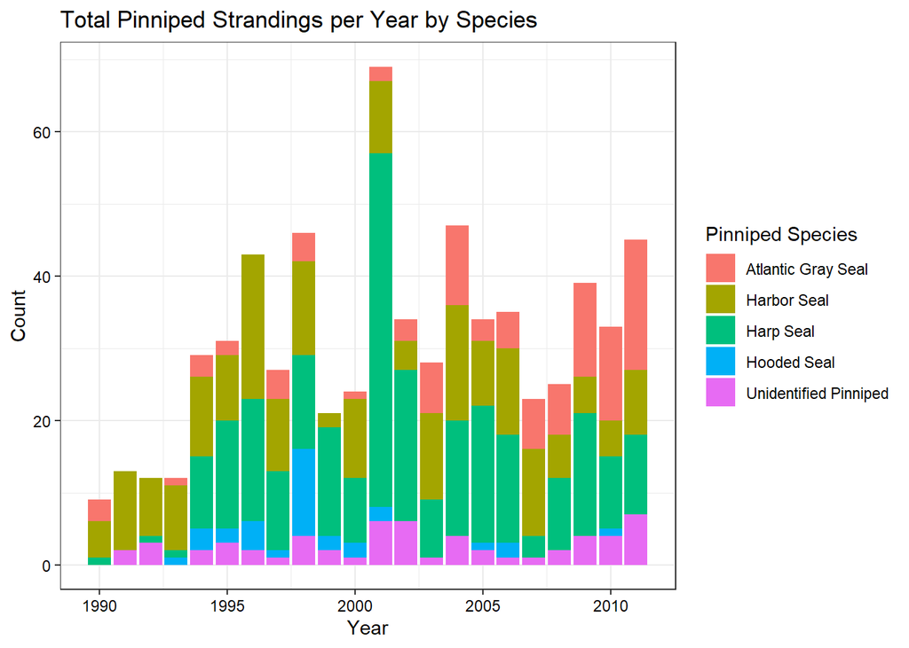

```r
ggplot(Pinniped_Stranding_Data) +
  geom_bar(aes(x = Year, fill = common_name)) +
  ylab("Count") +
  labs(title = "Total Pinniped Strandings per Year by Species") +
  scale_fill_discrete(name = "Pinniped Species", labels = c("Atlantic Gray Seal", "Harbor Seal", "Harp Seal", "Hooded Seal", "Unidentified Pinniped"))
```

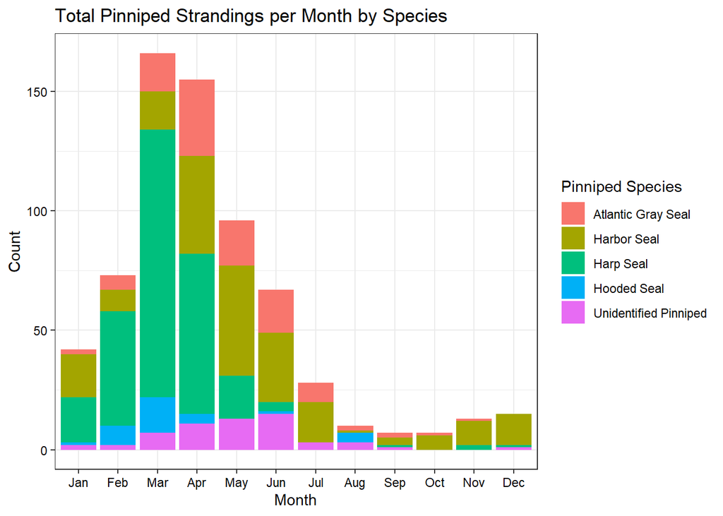

```r
ggplot(Pinniped_Stranding_Data) +
  geom_bar(aes(x = Month, fill = common_name)) +
  ylab("Count") +
  labs(title = "Total Pinniped Strandings per Month by Species") +
  scale_fill_discrete(name = "Pinniped Species", labels = c("Atlantic Gray Seal", "Harbor Seal", "Harp Seal", "Hooded Seal", "Unidentified Pinniped")) +
  scale_x_discrete(name = "Month",
                   limits = c("Jan","Feb","Mar","Apr","May","Jun","Jul","Aug","Sep","Oct","Nov","Dec"))
```

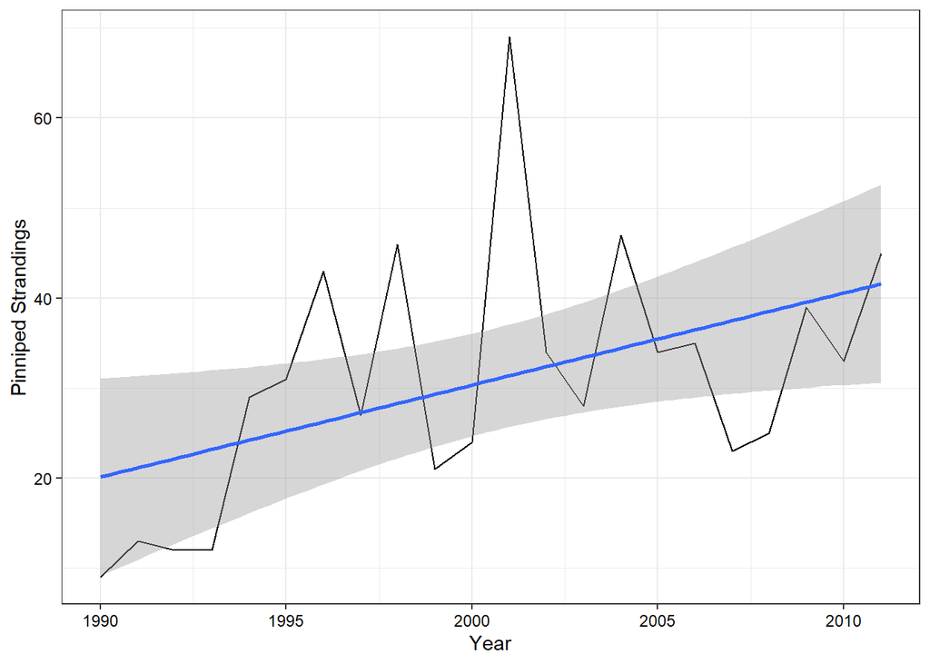

```r
Pinniped_Stranding_Plot <-
ggplot(Annual_Pinniped_Strandings, aes(x = Year, y = Pinnipeds_Total)) +
  geom_line() +
  ylab("Pinniped Strandings") +
  geom_smooth( method = lm )

print(Pinniped_Stranding_Plot)
```

Possible overall increasing trend in pinniped strandings and possible monthly/seasonal trend.

```r
Pinniped_sf <- Pinniped_Stranding_Data %>%
  st_as_sf(coords = c("longitude", "latitude"), crs = 4326)

mapview(Pinniped_sf)
```

[interactive chart not shown]

> Pinniped Analysis

> > Statisical Analysis

Null Hypothesis 1: There is no effect of year on the total number of pinniped strandings Alternative Hypothesis 1: There is an effect of year on the total number of pinniped strandings

Null Hypothesis 2: There is no effect of month on the total number of pinniped strandings Alternative Hypothesis 2: There is an effect of month on the total number of pinniped strandings

```r
Pinniped_Model <- aov(data = Annual_Pinniped_Strandings, Pinnipeds_Total ~ Year)

Pinniped_Model
```

```
## Call:
##    aov(formula = Pinnipeds_Total ~ Year, data = Annual_Pinniped_Strandings)
##
## Terms:
##                     Year Residuals
## Sum of Squares   923.908  3250.683
## Deg. of Freedom        1        20
##
## Residual standard error: 12.74889
## Estimated effects may be unbalanced
```

```r
summary.aov(Pinniped_Model)
```

```
##             Df Sum Sq Mean Sq F value Pr(>F)
## Year         1    924   923.9   5.684 0.0271 *
## Residuals   20   3251   162.5
## ---
## Signif. codes:  0 '***' 0.001 '**' 0.01 '*' 0.05 '.' 0.1 ' ' 1
```

```r
Pinniped_Model2 <- aov(data = Monthly_Pinniped_Strandings, Pinnipeds_Total ~ Month)

Pinniped_Model2
```

```
## Call:
##    aov(formula = Pinnipeds_Total ~ Month, data = Monthly_Pinniped_Strandings)
##
## Terms:
##                    Month Residuals
## Sum of Squares  15598.20  19736.72
## Deg. of Freedom        1        10
##
## Residual standard error: 44.42603
## Estimated effects may be unbalanced
```

```r
summary.aov(Pinniped_Model2)
```

```
##             Df Sum Sq Mean Sq F value Pr(>F)
## Month        1  15598   15598   7.903 0.0184 *
## Residuals   10  19737    1974
## ---
## Signif. codes:  0 '***' 0.001 '**' 0.01 '*' 0.05 '.' 0.1 ' ' 1
```

We reject the null hypothesis that there is no effect of year on the total number of pinniped strandings due to a p-value of 0.027. We also reject the null hypothesis that there is no effect of month on the total number of pinniped strandings due to a p-value of 0.018. These effects could likely be explained by differing environmental factors each year, however our dataset did not include such data. This could be an avenue of further research for a future project, if such environmental data is available.

> > Geospatial Analysis

```r
Pinniped_sf_utm <- st_transform(Pinniped_sf,32619)
#The data points straddle UTM zones 18 and 19, zone 19 was chosen because that is where the greatest concentration of points seems to be located.

Pinniped_sf_utm$geometry
```

```
## Geometry set for 679 features
## Geometry type: POINT
## Dimension:     XY
## Bounding box:  xmin: 115345.6 ymin: 4551593 xmax: 322648.9 ymax: 4637243
## Projected CRS: WGS 84 / UTM zone 19N
## First 5 geometries:
```

```
## POINT (293586.9 4585397)
```

```
## POINT (297917.1 4595261)
```

```
## POINT (291463.9 4582510)
```

```
## POINT (297812.2 4601441)
```

```
## POINT (310031.7 4594484)
```

```r
long_mean <- mean(Pinniped_Stranding_Data$longitude)
lat_mean <- mean(Pinniped_Stranding_Data$latitude)

Pinniped_Stranding_Mean_Point <- data.frame(long_mean, lat_mean)

Pinniped_Mean_sf <- Pinniped_Stranding_Mean_Point %>%
  st_as_sf(coords = c("long_mean", "lat_mean"), crs = 4326)

Pinniped_Mean_UTM <- st_transform(Pinniped_Mean_sf,32619)


Pinniped_Distance_Matrix <- st_distance(Pinniped_sf_utm, Pinniped_sf_utm, pairwise = T)

mean_distance <-  rowMeans(Pinniped_Distance_Matrix)

Pinniped_sf_utm  <-  Pinniped_sf_utm %>%
  bind_cols(mean_distance = mean_distance)
```

```r
mapview(Pinniped_sf_utm,
        zcol = "mean_distance",
        layer.name = "Distance (m) from Mean Stranding Point")
```

[interactive chart not shown]

Knowing where the “mean” stranding location is could allow for a study of that area in order to determine why pinniped strandings are so prominent on this area and allow for the allocation of more recovery resources and personnel to that area to compensate for the higher levels of strandings.

```r
# points within 40,000m
Pinniped_40 <- Pinniped_sf_utm %>%
  filter(mean_distance < 40000) %>%
  mutate(distance_group = "< 40,000")

# points between 40,000m - 60,000m
Pinniped_40_60 <- Pinniped_sf_utm %>%
  filter(mean_distance >= 40000 & mean_distance < 60000) %>%
  mutate(distance_group = "40,000 - 60,000")

# points between 60,000m - 80,000m
Pinniped_60_80 <- Pinniped_sf_utm %>%
  filter(mean_distance >= 60000 & mean_distance < 80000) %>%
  mutate(distance_group = "60,000 - 80,000")

# points between 80,000m - 100,000m
Pinniped_80_100 <- Pinniped_sf_utm %>%
  filter(mean_distance >= 80000 & mean_distance < 100000) %>%
  mutate(distance_group = "80,000 - 100,000")

# points between 100,000m - 120,000m
Pinniped_100_120 <- Pinniped_sf_utm %>%
  filter(mean_distance >= 100000 & mean_distance < 120000) %>%
  mutate(distance_group = "100,000 - 120,000")

# points between 120,000m - 140,000m
Pinniped_120_140 <- Pinniped_sf_utm %>%
  filter(mean_distance >= 120000 & mean_distance < 140000) %>%
  mutate(distance_group = "120,000 - 140,000")

# points between 140,000m - 160,000m
Pinniped_140_160 <- Pinniped_sf_utm %>%
  filter(mean_distance >= 140000 & mean_distance < 160000) %>%
  mutate(distance_group = "140,000 - 160,000")

# points greater than 160,000m
Pinniped_160 <- Pinniped_sf_utm %>%
  filter(mean_distance >= 160000) %>%
  mutate(distance_group = "> 160,000")

# row bind the distance dataframes
Pinniped_sf_utm_final <- rbind(Pinniped_40, Pinniped_40_60, Pinniped_60_80, Pinniped_80_100, Pinniped_100_120, Pinniped_120_140, Pinniped_140_160, Pinniped_160)

Pinniped_distances <- Pinniped_sf_utm_final %>%
  group_by(distance_group) %>%
  summarise(totals_by_distance = n()) %>%
  st_drop_geometry() %>%
  arrange(totals_by_distance)

kable(Pinniped_distances)
```

| distance_group | totals_by_distance |
| --- | --- |
| > 160,000 | 3 |
| 100,000 - 120,000 | 7 |
| 140,000 - 160,000 | 7 |
| 120,000 - 140,000 | 11 |
| 80,000 - 100,000 | 11 |
| 60,000 - 80,000 | 15 |
| 40,000 - 60,000 | 200 |
| < 40,000 | 425 |

> > Temporal Analysis

Null Hypothesis: The yearly and/or monthly/seasonal pinniped stranding data is stationary Alternative Hypothesis: The yearly and/or monthly/seasonal pinniped stranding data is not stationary

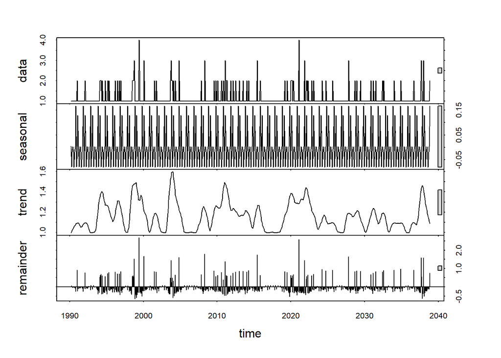

```r
f_month <- month(first(Pinniped_Stranding_Totals$Date))
f_year <- year(first(Pinniped_Stranding_Totals$Date))


Pinniped_ts_monthly <- ts(Pinniped_Stranding_Totals$Total,
                  start = c(f_year, f_month),
                  frequency = 12)

Pinniped_ts_monthly_decomp <- stl(Pinniped_ts_monthly, s.window = "periodic")
plot(Pinniped_ts_monthly_decomp)
```

```r
Pinniped_ts_monthly_trend <- Kendall::SeasonalMannKendall(Pinniped_ts_monthly)

summary(Pinniped_ts_monthly_trend)
```

```
## Score =  -163 , Var(Score) = 54217
## denominator =  6740.981
## tau = -0.0242, 2-sided pvalue =0.48391
```

Fail to reject the H0 that monthly pinniped strandings are stationary, with a p-value of 0.48, but there could be some seasonality based on this graph.

```r
Pinniped_ts_yearly <- ts(Pinniped_Stranding_Totals, start = c(1990,1), frequency = 1)

Pinniped_ts_yearly_trend <- Kendall::SeasonalMannKendall(Pinniped_ts_yearly)

summary(Pinniped_ts_yearly_trend)
```

```
## Score =  -173389 , Var(Score) = 163714576
## denominator =  615460.9
## tau = -0.282, 2-sided pvalue =< 2.22e-16
```

Reject the H0 that yearly pinniped strandings are stationary with a p-value or 2.22e-16.